# Gapminder Exploration Part III

Kenny Chiu

2019-10-01

## Navigation

Back to the [repository](https://github.com/STAT545-UBC-hw-2019-20/stat545-hw-chiukenny/tree/master/hw03).

## Introduction

We explore the `gapminder` dataset available in the `gapminder` R package. This exploration also uses the `tidyverse` R package.

The CSS used to create the column presentation in this exploration is based on Omar AlOmeir’s [CSS file](https://gist.github.com/jennybc/e9e9aba6ba18c72cec26) as well as examples from [MDN](https://developer.mozilla.org/en-US/docs/Web/CSS/Using_CSS_custom_properties).

## Task Option 1: Countries with Low Life Expectancy

We report the relative abundance of countries with low life expectancy over time by continent. We define that a country has low life expectancy if its life expectancy is below the median life expectancy across all countries for that year. The following plot and table show the number of countries with low life expectancy by continent over time. Note that **continents with 0 low life expectancy countries for a given year are excluded from both the plot and table**.

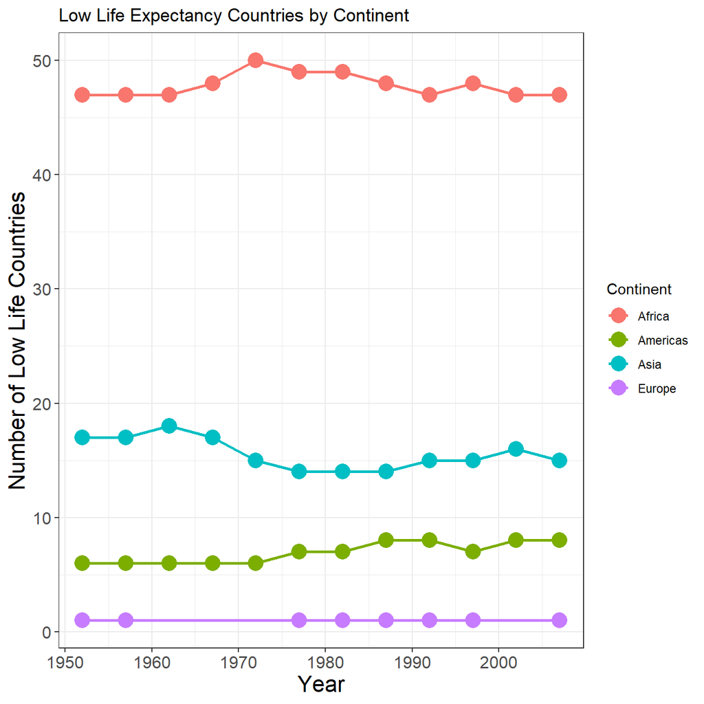

|  | year | continent | lowLifeExpCount |
| --- | --- | --- | --- |
| 1 | 1952 | Africa | 47 |
| 2 | 1952 | Americas | 6 |
| 3 | 1952 | Asia | 17 |
| 4 | 1952 | Europe | 1 |
| 5 | 1957 | Africa | 47 |
| 6 | 1957 | Americas | 6 |
| 7 | 1957 | Asia | 17 |
| 8 | 1957 | Europe | 1 |
| 9 | 1962 | Africa | 47 |
| 10 | 1962 | Americas | 6 |

[output cut: 34 more lines]

```r
dat = gapminder %>%
  group_by(year) %>%
  filter(lifeExp < median(lifeExp)) %>%
  group_by(year, continent) %>%
  summarize(lowLifeExpCount = length(continent))

# Code for plot
t1plot = dat %>%
  ggplot(aes(year, lowLifeExpCount, group = continent, colour = continent)) +
  geom_line(size = 1) +
  geom_point(size = 5) +
  labs(title = "Low Life Expectancy Countries by Continent",
       x = "Year", y = "Number of Low Life Countries",
       colour = "Continent") +
  theme_bw() +
  theme(axis.text = element_text(size = 12), axis.title = element_text(size = 16))

# Code for table
t1table = DT::datatable(dat)
```

We see that the majority of countries with low life expectancy are African countries. We also see that the two countries in the Oceania region have never had a low life expectancy since 1952.

The following plot compares the life expectancy of low life expectancy countries to the median life expectancy (black bar) over time. The table shows the life expectancy of these countries. Note that **the points under a single bar are observations for a given year but jittered horizontally to improve visibility**.

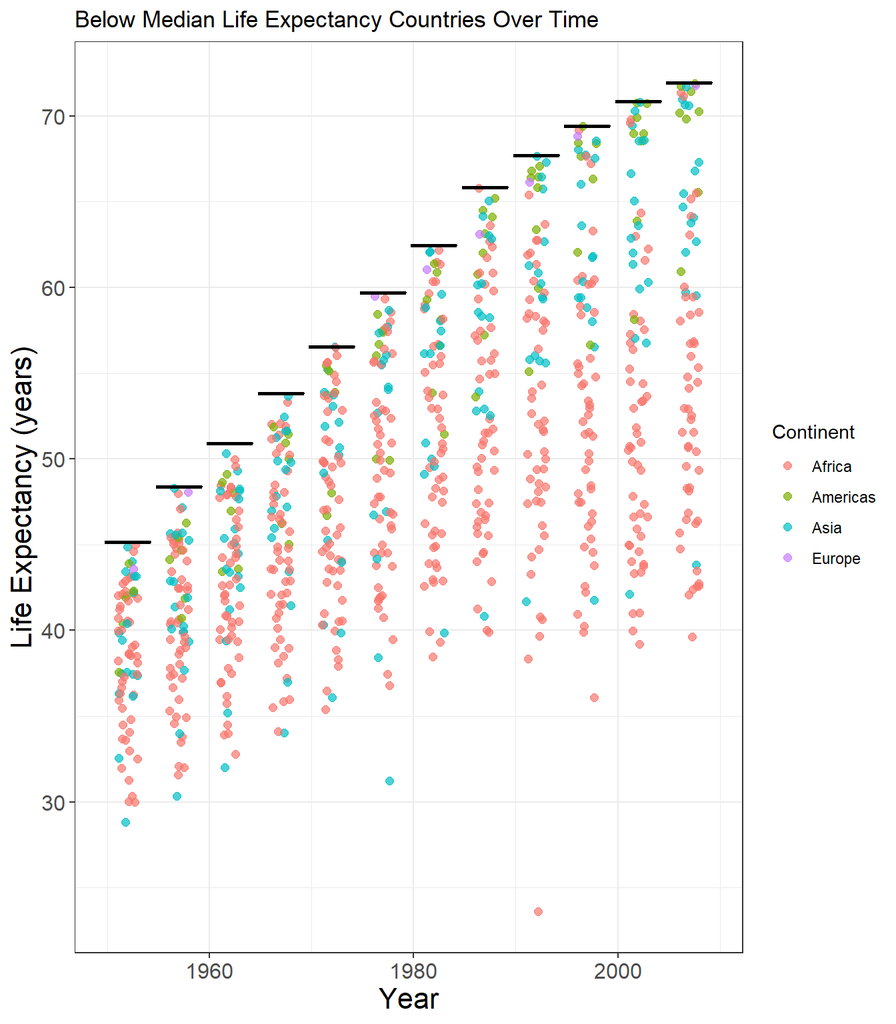

|  | year | continent | country | lifeExp |
| --- | --- | --- | --- | --- |
| 1 | 1952 | Asia | Afghanistan | 28.801 |
| 2 | 1957 | Asia | Afghanistan | 30.332 |
| 3 | 1962 | Asia | Afghanistan | 31.997 |
| 4 | 1967 | Asia | Afghanistan | 34.02 |
| 5 | 1972 | Asia | Afghanistan | 36.088 |
| 6 | 1977 | Asia | Afghanistan | 38.438 |
| 7 | 1982 | Asia | Afghanistan | 39.854 |
| 8 | 1987 | Asia | Afghanistan | 40.822 |
| 9 | 1992 | Asia | Afghanistan | 41.674 |
| 10 | 1997 | Asia | Afghanistan | 41.763 |

[output cut: 842 more lines]

```r
dat = gapminder %>%
  group_by(year)

datf = dat %>%
  filter(lifeExp < median(lifeExp)) %>%
  select(year, continent, country, lifeExp)

# Code for plot
# Note: would like to label the medians but it is not simple with our current setup
t1plot2 = datf %>%
  ggplot(aes(year, lifeExp, colour = continent)) +
  geom_jitter(height = 0, width = 1, size = 2, alpha = 0.7) +
  stat_summary(data = dat, fun.y = median, fun.ymin = median, fun.ymax = median,
               colour = "black", size = 0.4, geom = "crossbar") +
  labs(title = "Below Median Life Expectancy Countries Over Time",
       x = "Year", y = "Life Expectancy (years)",
       colour = "Continent") +
  theme_bw() +
  theme(axis.text = element_text(size = 12), axis.title = element_text(size = 16))

# Code for table
t1table2 = datf %>%
  DT::datatable() %>%
  DT::formatRound(columns = c("lifeExp"), digits = 2)
```

We see that many of the African countries have a life expectancy well-below the median life expectancy, whereas the majority of other low life expectancy countries are relatively closer to the median.

## Task Option 2: Range of GDP per Capita for Each Continent

The following plot and table show the minimum and maximum of GDP per capita for all continents.

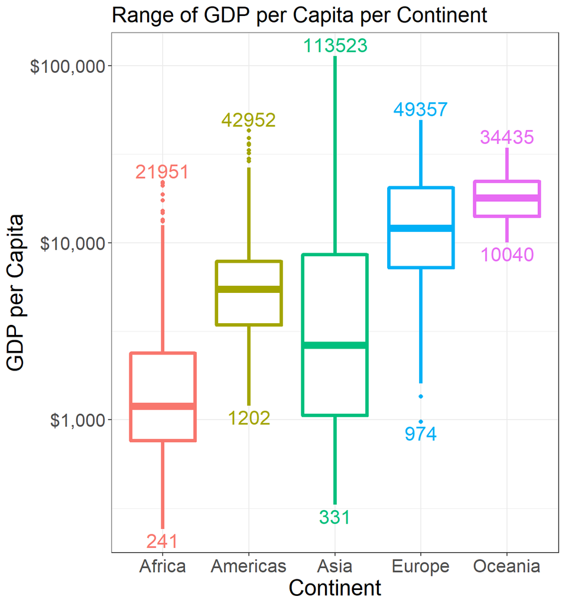

|  | continent | minCountry | minGdpCap | maxCountry | maxGdpCap |
| --- | --- | --- | --- | --- | --- |
| 1 | Africa | Congo, Dem. Rep. | 241.1658765 | Libya | 21951.21176 |
| 2 | Americas | Haiti | 1201.637154 | United States | 42951.65309 |
| 3 | Asia | Myanmar | 331 | Kuwait | 113523.1329 |
| 4 | Europe | Bosnia and Herzegovina | 973.5331948 | Norway | 49357.19017 |
| 5 | Oceania | Australia | 10039.59564 | Australia | 34435.36744 |

```r
# Code for plot
t2plot = gapminder %>%
  ggplot(aes(continent, gdpPercap, colour = continent)) +
  geom_boxplot(size = 1.5) +
  scale_y_log10(labels = scales::dollar_format()) +
  stat_summary(aes(label = round(10^..y..)), fun.y = min, geom = "text", size = 6, vjust = 1.3) +
  stat_summary(aes(label = round(10^..y..)), fun.y = max, geom = "text", size = 6, vjust = -0.3) +
  labs(title = "Range of GDP per Capita per Continent", x = "Continent", y = "GDP per Capita") +
  theme_bw() +
  theme(legend.position = "none", title = element_text(size = 16),
        axis.text = element_text(size = 16), axis.title = element_text(size = 20))

# Code for table
t2table = gapminder %>%
  group_by(continent) %>%
  summarize(minGdpCap = min(gdpPercap), minCountry = country[gdpPercap == minGdpCap],
            maxGdpCap = max(gdpPercap), maxCountry = country[gdpPercap == maxGdpCap]) %>%
  select(continent, minCountry, minGdpCap, maxCountry, maxGdpCap) %>%
  DT::datatable() %>%
  DT::formatRound(columns = c("minGdpCap", "maxGdpCap"), digits = 2)
```

We see that Asia has the widest range of GDP per capita with Myanmar having the lowest GDP and Kuwait having the highest in Asia. Across all continents and years, the Democratic Republic of the Congo has the lowest GDP per capita and Kuwait has the highest.

## Task Option 4: Mean Life Expectancy Weighted by Population

The following plot and table show the mean life expectancy weighted by population in comparison to the unweighted mean life expectancy over time. Also plotted are the life expectancy of countries **for a given year but jittered horizontally to improve visibility**.

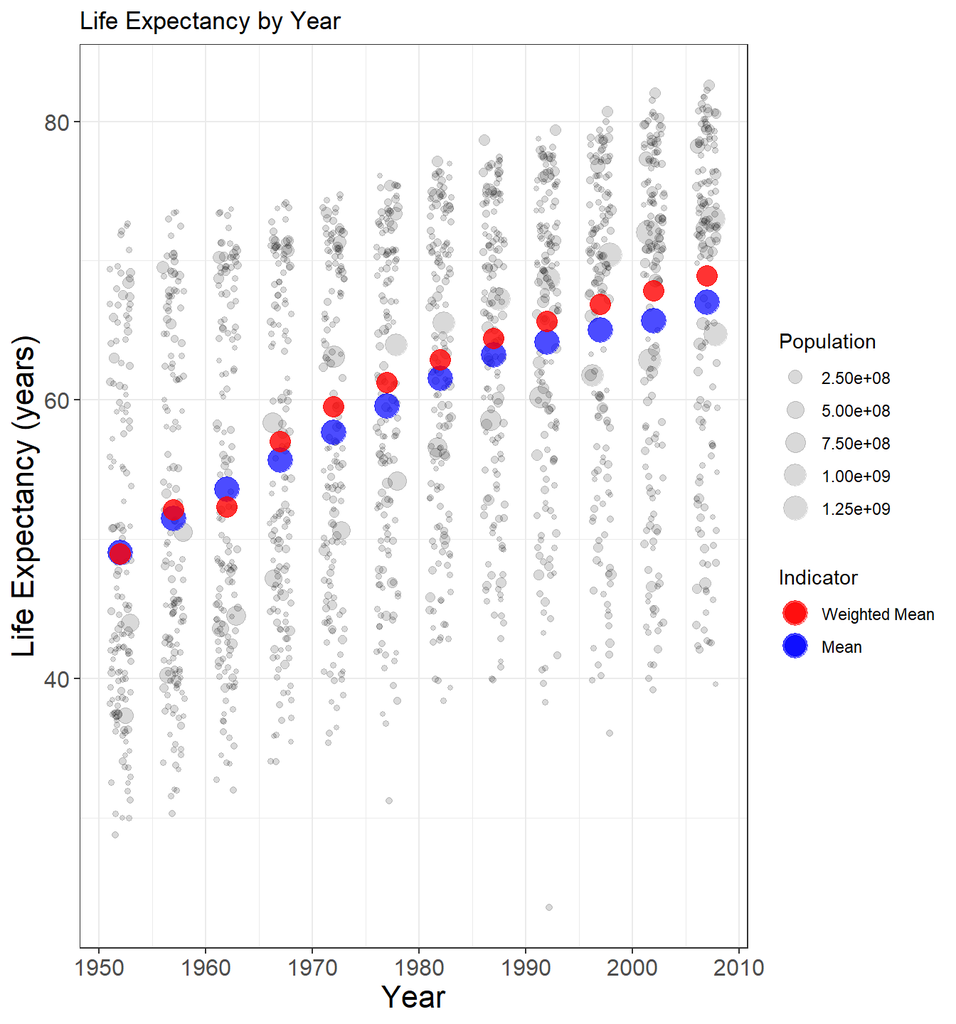

|  | year | meanLifeExp | wMeanLifeExp |
| --- | --- | --- | --- |
| 1 | 1952 | 49.0576197183099 | 48.9442367328978 |
| 2 | 1957 | 51.5074011267606 | 52.1218850827385 |
| 3 | 1962 | 53.6092490140845 | 52.3243820828789 |
| 4 | 1967 | 55.6782895774648 | 56.9843067912689 |
| 5 | 1972 | 57.6473864788732 | 59.5147829246504 |
| 6 | 1977 | 59.5701574647887 | 61.2372559476396 |
| 7 | 1982 | 61.5331971830986 | 62.8817553917975 |
| 8 | 1987 | 63.2126126760563 | 64.4163500580769 |
| 9 | 1992 | 64.160338028169 | 65.6458996955676 |
| 10 | 1997 | 65.014676056338 | 66.8493429481753 |

[output cut: 2 more lines]

```r
dat = gapminder %>%
  group_by(year) %>%
  summarize(meanLifeExp = mean(lifeExp),
            wMeanLifeExp = weighted.mean(lifeExp, pop))

# Code for plot
# Manual legend code from https://aosmith.rbind.io/2018/07/19/manual-legends-ggplot2/
t3plot = dat %>%
  ggplot(aes(year, wMeanLifeExp)) +
  geom_jitter(aes(year, lifeExp, size = pop), data = gapminder, height = 0, width = 1, alpha = 0.15) +
  geom_point(aes(year, meanLifeExp, colour = "blue"), size = 6, alpha = 0.7) +
  geom_point(aes(colour = "red"), size = 5, alpha = 0.8) +
  labs(title = "Life Expectancy by Year",
       x = "Year", y = "Life Expectancy (years)",
       size = "Population") +
  scale_colour_identity(name = "Indicator", breaks = c("red", "blue"), labels = c("Weighted Mean", "Mean"),
                        guide = "legend") +
  theme_bw() +
  theme(axis.text = element_text(size = 12), axis.title = element_text(size = 16))

# Code for table
t3table = dat %>%
  DT::datatable() %>%
  DT::formatRound(columns = c("meanLifeExp", "wMeanLifeExp"), digits = 2)
```